# 360HW1

Arda Oru

2024-04-02

## Results and Analysis

The aim of this assignment is to predict 3 independent variables using different datasets. Time series variables to be estimated are Antalya housing sales(Antalya.konut.satış), passenger vehicle production(binek.taşıt.üretim) and consumer confidence index (tüketici.güven.endeksi).When selecting independent variables, care was taken to ensure that they were not correlated with each other and were related to the prediction variable.

When estimating passenger vehicle production, I paid attention to the following points: I used the EU consumer price index since a significant part of Turkey’s vehicle production is exported to Europe. In addition, due to the automotive industry, which occupies a significant share in the Turkish industry, I added the capacity utilization rate in our industry to my data sets. Finally, I used passenger vehicle export data to take non-European exports into account.

While predicting Antalya housing sales, I added the housing price index and loan interest rates to my analysis.

Finally, I added total credit and debit card expenditures and unemployment data to my analysis to estimate the consumer confidence index. The reason why I added total card expenditures is my assumption that the consumer price index and expenditures will have a linear relationship. If trust is low, consumers will be more savings-oriented and reduce their spending. Additionally, unemployment should be one of the most important parts of the confidence index.

```r
require(data.table)
require(lubridate)
require(forecast)
require(skimr)
require(repr)
require(openxlsx)
```

```r
require(ggplot2)
require(data.table)
require(skimr)
require(GGally)
require(ggcorrplot)
require(forecast)
```

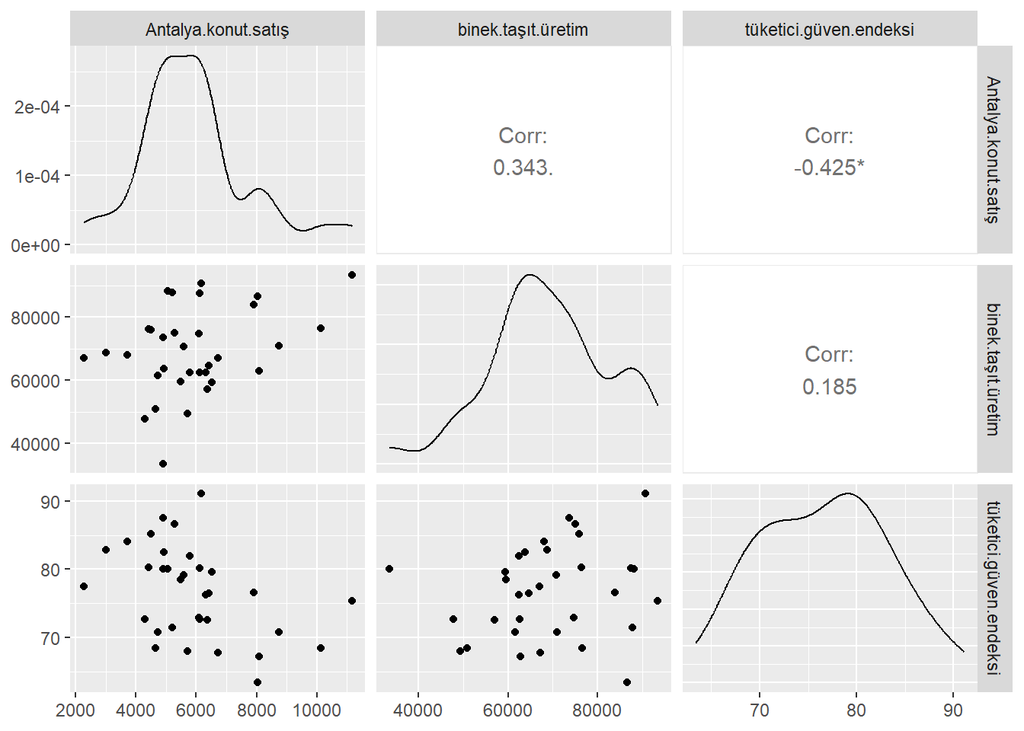

```r
data_path = "C:\\Users\\ardao\\Desktop\\cor.xlsx"
cor=read.xlsx(data_path)
ggpairs(cor)
```

## Data preperation

Below, I prepared related data.

```r
options(repr.plot.width=12.7, repr.plot.height=8.5)

data_path = "C:\\Users\\ardao\\Desktop\\antalya_konut_satisi.xlsx"
konut=read.xlsx(data_path)
head(konut,5)
```

```
##     Tarih Konut_kredi_faizleri Antalya_isparta_Konut_fiyat_endeksi
## 1 2021-01   18.388000000000002                               190.9
## 2 2021-02   17.984999999999999                               195.0
## 3 2021-03   17.734999999999999                               199.0
## 4 2021-04               18.134                               206.2
## 5 2021-05   17.835000000000001                               216.3
##   Antalya_konut_satis
## 1                3010
## 2                3702
## 3                5268
## 4                4429
## 5                2264
```

```r
str(konut)
```

```
## 'data.frame':    46 obs. of  4 variables:
##  $ Tarih                              : chr  "2021-01" "2021-02" "2021-03" "2021-04" ...
##  $ Konut_kredi_faizleri               : chr  "18.388000000000002" "17.984999999999999" "17.734999999999999" "18.134" ...
##  $ Antalya_isparta_Konut_fiyat_endeksi: num  191 195 199 206 216 ...
##  $ Antalya_konut_satis                : num  3010 3702 5268 4429 2264 ...
```

```r
require(lubridate)
konut$Tarih <- ym(konut$Tarih)
konut$Konut_kredi_faizleri <- as.numeric(konut$Konut_kredi_faizleri)
head(konut)
```

```
##        Tarih Konut_kredi_faizleri Antalya_isparta_Konut_fiyat_endeksi
## 1 2021-01-01               18.388                               190.9
## 2 2021-02-01               17.985                               195.0
## 3 2021-03-01               17.735                               199.0
## 4 2021-04-01               18.134                               206.2
## 5 2021-05-01               17.835                               216.3
## 6 2021-06-01               17.900                               222.4
##   Antalya_konut_satis
## 1                3010
## 2                3702
## 3                5268
## 4                4429
## 5                2264
## 6                5773
```

```r
data_path= "C:\\Users\\ardao\\Desktop\\binek_tasit_uretim.xlsx"
tasit=read.xlsx(data_path)
head(tasit,5)
```

```
##     Tarih kapasite_kullanim ab_fiyat_endeksi binek_tasit_ihracat
## 1 2021-01              75.6         113.0832           110.32151
## 2 2021-02              75.5         113.3194           115.18405
## 3 2021-03              75.6         114.3823           134.34682
## 4 2021-04              76.2         115.0373           116.79690
## 5 2021-05              75.2         115.3380            92.06025
##   binek_tasit_uretim
## 1              68777
## 2              68105
## 3              74995
## 4              76334
## 5              66976
```

```r
str(tasit)
```

```
## 'data.frame':    33 obs. of  5 variables:
##  $ Tarih              : chr  "2021-01" "2021-02" "2021-03" "2021-04" ...
##  $ kapasite_kullanim  : num  75.6 75.5 75.6 76.2 75.2 76.3 76.4 76.8 77.8 77.5 ...
##  $ ab_fiyat_endeksi   : num  113 113 114 115 115 ...
##  $ binek_tasit_ihracat: num  110.3 115.2 134.3 116.8 92.1 ...
##  $ binek_tasit_uretim : num  68777 68105 74995 76334 66976 ...
```

```r
tasit$Tarih <- ym(tasit$Tarih)
head(tasit)
```

```
##        Tarih kapasite_kullanim ab_fiyat_endeksi binek_tasit_ihracat
## 1 2021-01-01              75.6         113.0832           110.32151
## 2 2021-02-01              75.5         113.3194           115.18405
## 3 2021-03-01              75.6         114.3823           134.34682
## 4 2021-04-01              76.2         115.0373           116.79690
## 5 2021-05-01              75.2         115.3380            92.06025
## 6 2021-06-01              76.3         115.6386            84.00333
##   binek_tasit_uretim
## 1              68777
## 2              68105
## 3              74995
## 4              76334
## 5              66976
## 6              62441
```

```r
data_path = "C:\\Users\\ardao\\Desktop\\tuketici_guven_endeksi.xlsx"
guven=read.xlsx(data_path)
head(guven,5)
```

```
##     Tarih USD_Banka_Karti_ve_Kredi_Karti_Harcama_tutari issizlik_oranlar
## 1 2021-01                                      15546455             13.4
## 2 2021-02                                      13992938             14.1
## 3 2021-03                                      13981868             13.1
## 4 2021-04                                      16022046             12.9
## 5 2021-05                                      11931825             12.4
##   tuketici_guven_endeksi
## 1               82.86952
## 2               84.10742
## 3               86.62952
## 4               80.25357
## 5               77.52774
```

```r
str(guven)
```

```
## 'data.frame':    33 obs. of  4 variables:
##  $ Tarih                                        : chr  "2021-01" "2021-02" "2021-03" "2021-04" ...
##  $ USD_Banka_Karti_ve_Kredi_Karti_Harcama_tutari: num  15546455 13992938 13981868 16022046 11931825 ...
##  $ issizlik_oranlar                             : num  13.4 14.1 13.1 12.9 12.4 10.4 12.1 12 11.1 10.7 ...
##  $ tuketici_guven_endeksi                       : num  82.9 84.1 86.6 80.3 77.5 ...
```

```r
guven$Tarih <- ym(guven$Tarih)
str(guven)
```

```
## 'data.frame':    33 obs. of  4 variables:
##  $ Tarih                                        : Date, format: "2021-01-01" "2021-02-01" ...
##  $ USD_Banka_Karti_ve_Kredi_Karti_Harcama_tutari: num  15546455 13992938 13981868 16022046 11931825 ...
##  $ issizlik_oranlar                             : num  13.4 14.1 13.1 12.9 12.4 10.4 12.1 12 11.1 10.7 ...
##  $ tuketici_guven_endeksi                       : num  82.9 84.1 86.6 80.3 77.5 ...
```

## Brief observations on forecast variables.

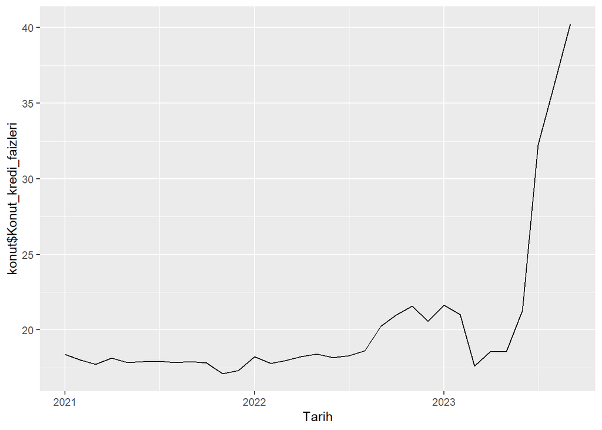

```r
ggplot(konut ,aes(x=Tarih,y=konut$Konut_kredi_faizleri)) + geom_line()
```

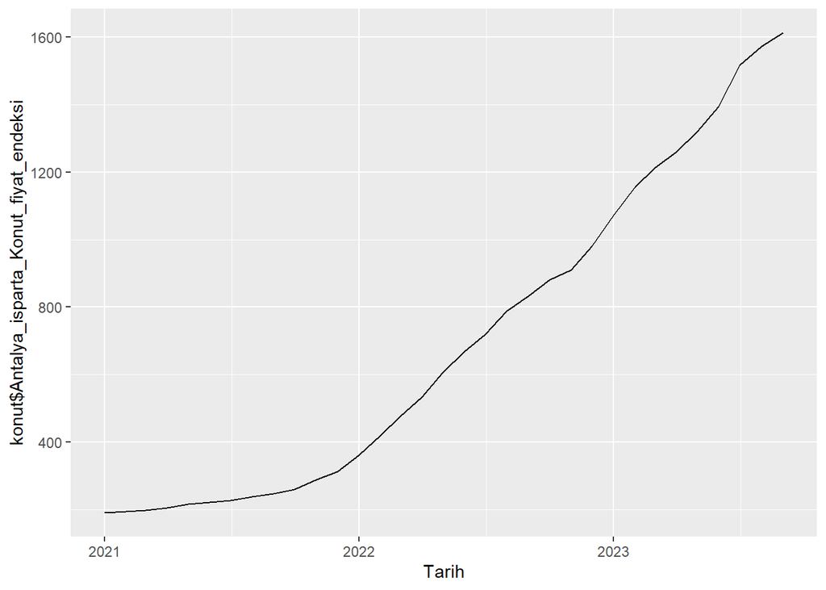

```r
ggplot(konut ,aes(x=Tarih,y=konut$Antalya_isparta_Konut_fiyat_endeksi)) + geom_line()
```

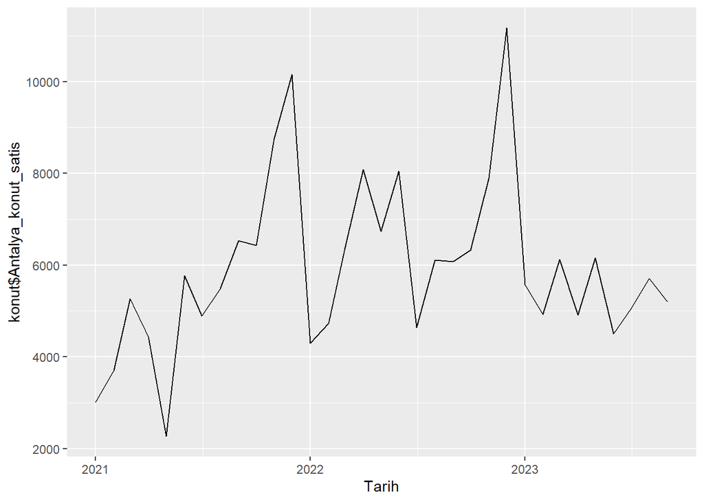

```r
ggplot(konut ,aes(x=Tarih,y=konut$Antalya_konut_satis)) + geom_line()
```

While housing loan interest rates have shown a sharp upward trend, especially in recent years, the housing price index has continued to increase linearly. Housing sales do not tend to show any trend, but there may be seasonality.

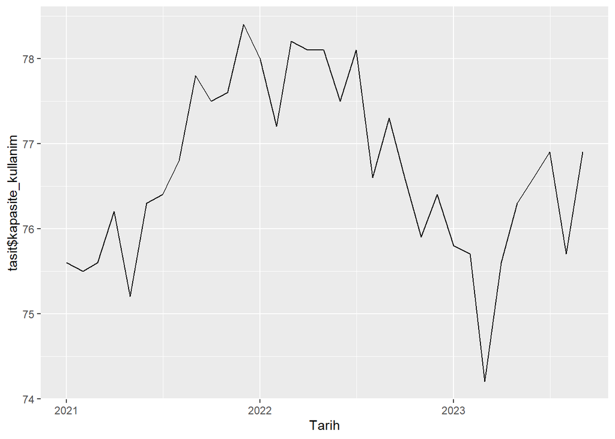

```r
ggplot(tasit ,aes(x=Tarih,y=tasit$kapasite_kullanim)) + geom_line()
```

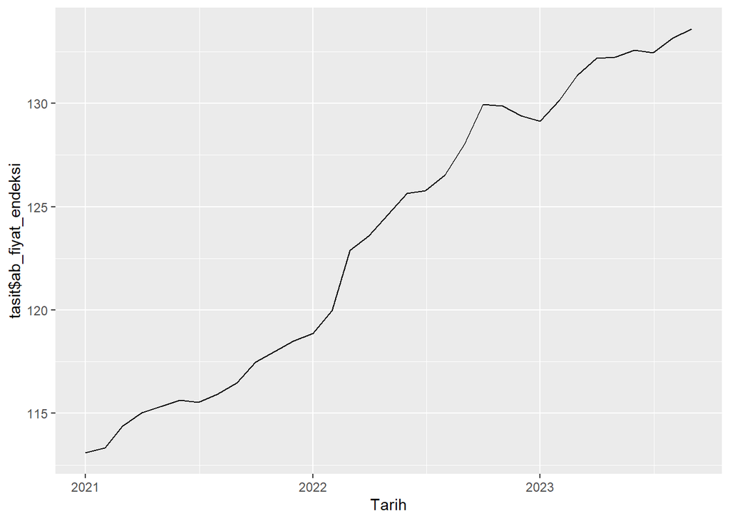

```r
ggplot(tasit ,aes(x=Tarih,y=tasit$ab_fiyat_endeksi)) + geom_line()
```

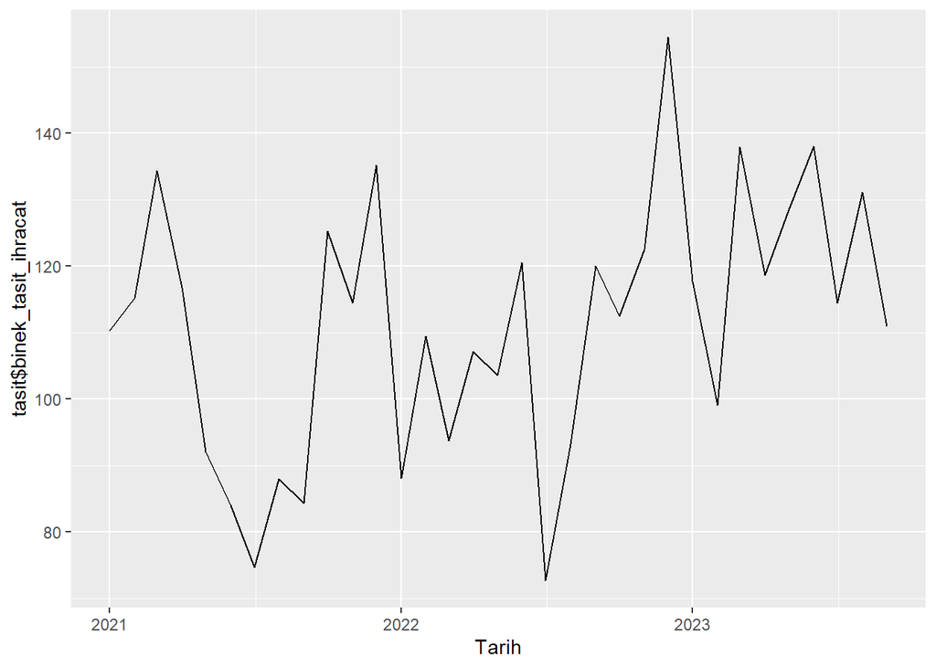

```r
ggplot(tasit ,aes(x=Tarih,y=tasit$binek_tasit_ihracat)) + geom_line()
```

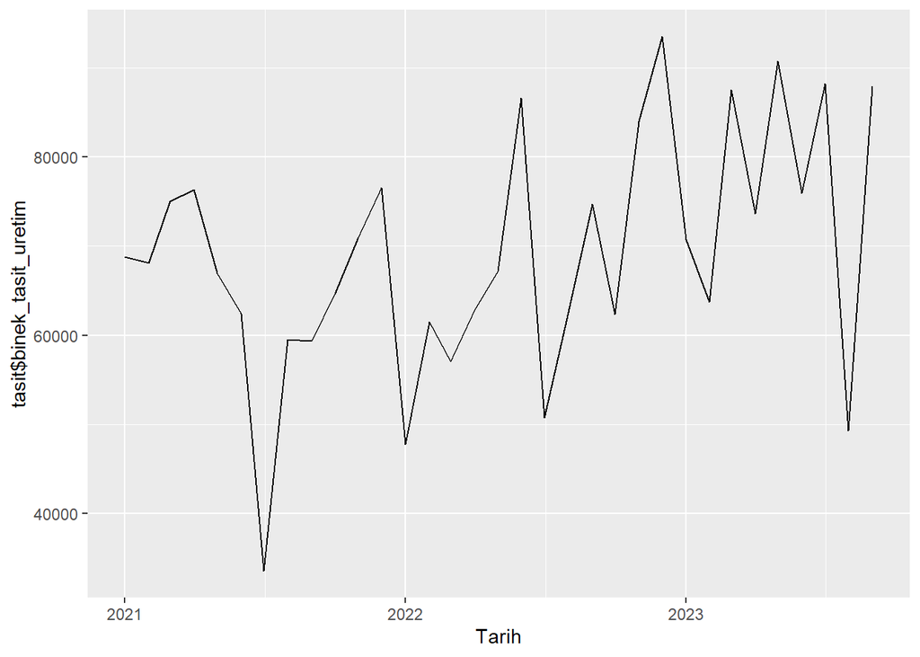

```r
ggplot(tasit ,aes(x=Tarih,y=tasit$binek_tasit_uretim)) + geom_line()
```

When the capacity utilization rate is examined, there is a regular decreasing trend from 2022 to mid-2023, followed by a recovery trend. The reason for the recovery may be the end of the economics of the presidential election and a return to orthodox economic policies.

The EU consumer price index has a linear upward trend.

There seems to be seasonality in passenger vehicle exports.

There seems to be seasonality and a very slightly increasing trend in passenger vehicle production.

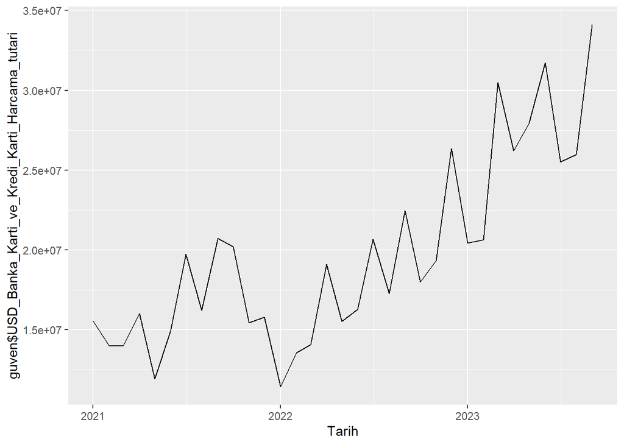

```r
ggplot(guven ,aes(x=Tarih,y=guven$USD_Banka_Karti_ve_Kredi_Karti_Harcama_tutari)) + geom_line()
```

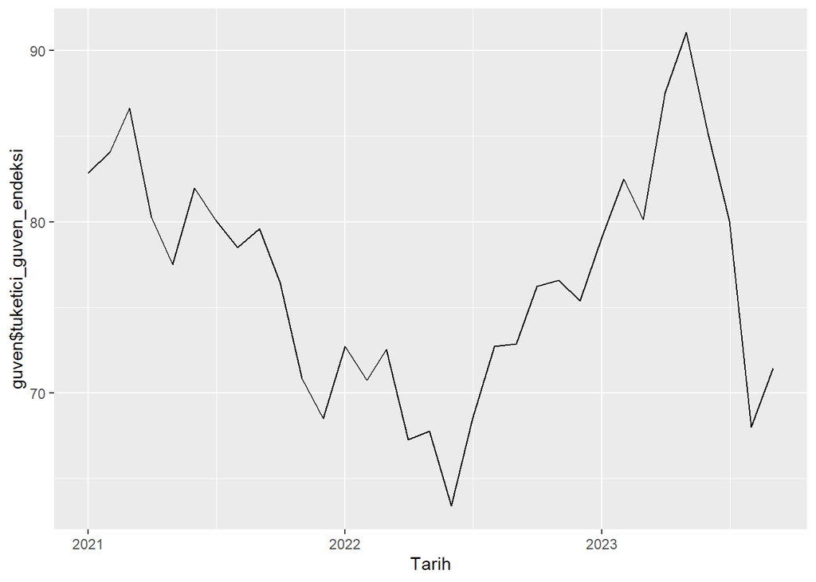

```r
ggplot(guven ,aes(x=Tarih,y=guven$tuketici_guven_endeksi)) + geom_line()
```

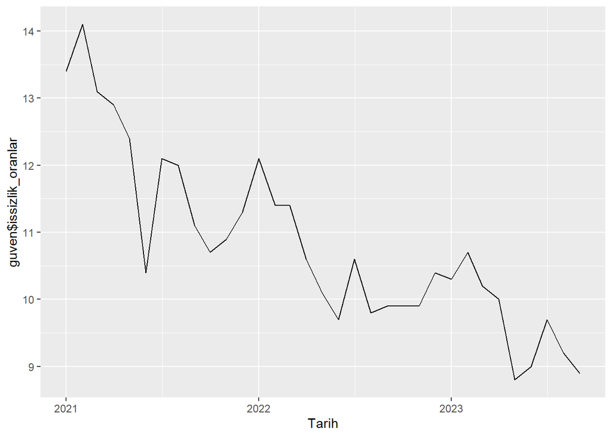

```r
ggplot(guven ,aes(x=Tarih,y=guven$issizlik_oranlar)) + geom_line()
```

In order to eliminate the exchange rate effect, I converted the card spending amounts into dollars by dividing them by the average exchange rates. However, it shows an increasing trend.

Unemployment generally tends to decrease. Really cheaper labor force and increased production and consumption demand after Covid may have contributed to this.

I could not make a clear comment about the consumer confidence index.

##Corelations

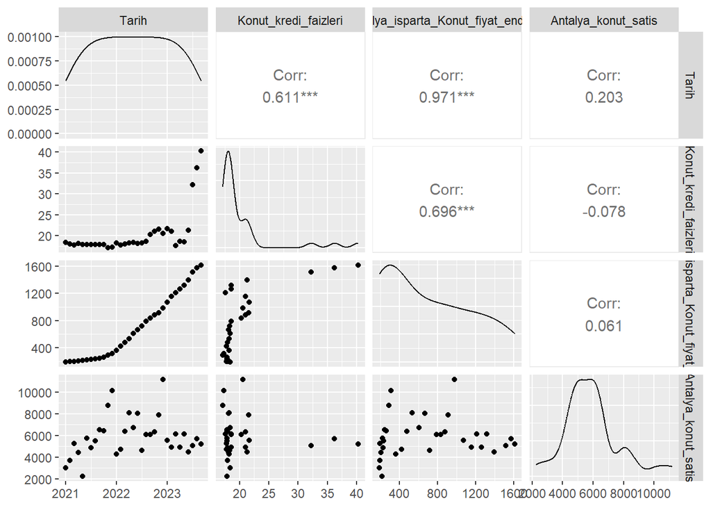

```r
require(GGally)
ggpairs(konut)
```

Here, there seems to be multicollinearity between loan interest rates and the housing price index. It might make sense to remove someone from the data set.

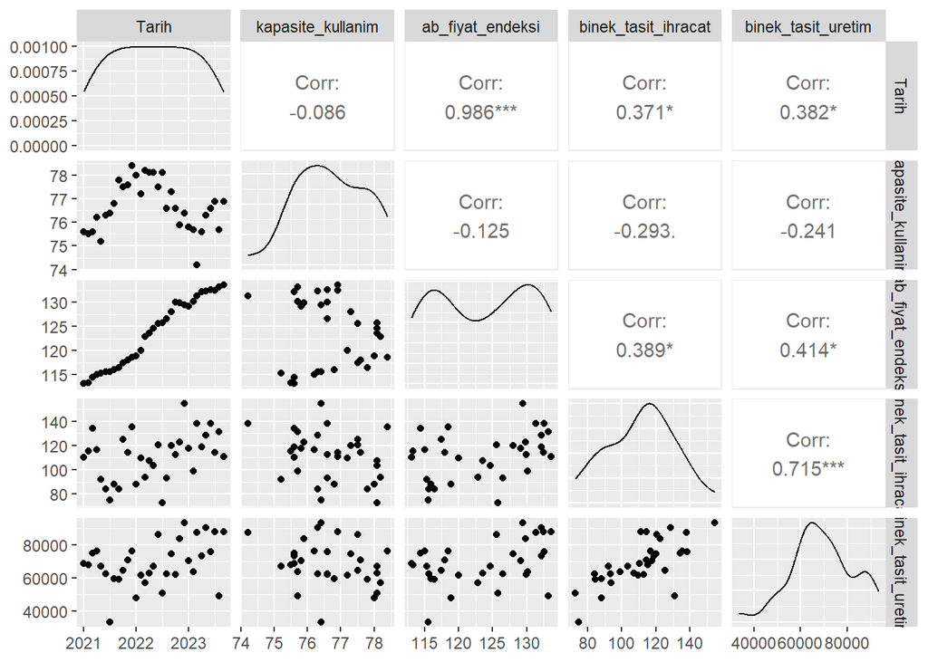

```r
ggpairs(tasit)
```

There doesn’t seem to be a problematic correlation here.

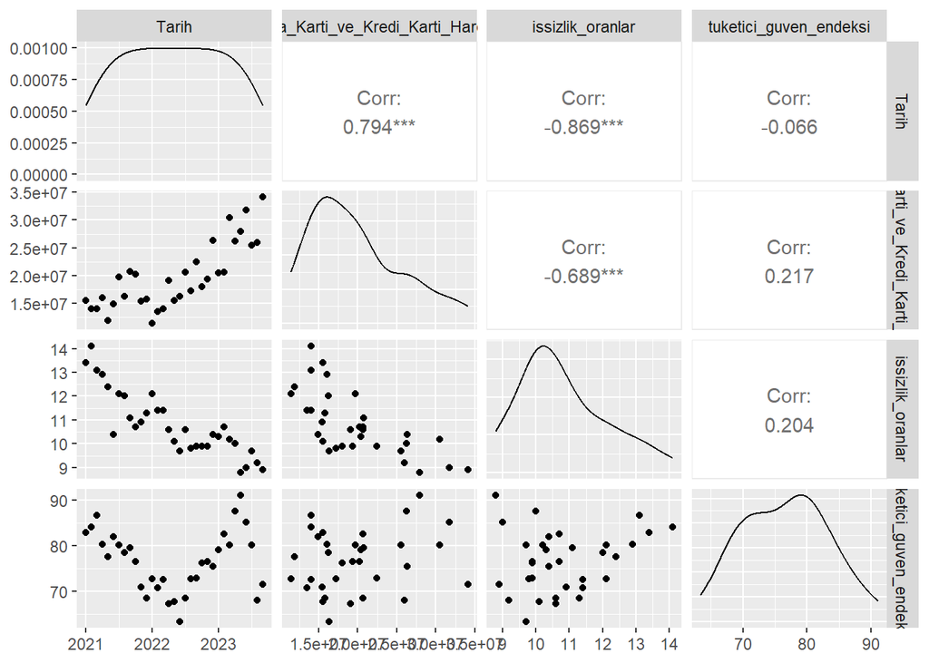

```r
ggpairs(guven)
```

There appears to be a high negative correlation between unemployment and card spending. This is quite plausible because as unemployment rises, spending will fall due to lost income.

## Linear trends

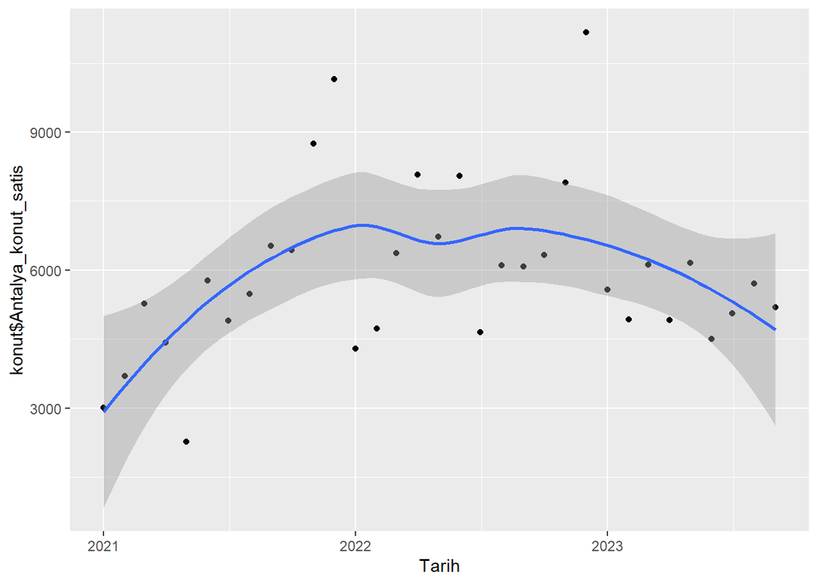

```r
ggplot(konut ,aes(x=Tarih,y=konut$Antalya_konut_satis)) + geom_point()+geom_smooth(method='loess')
```

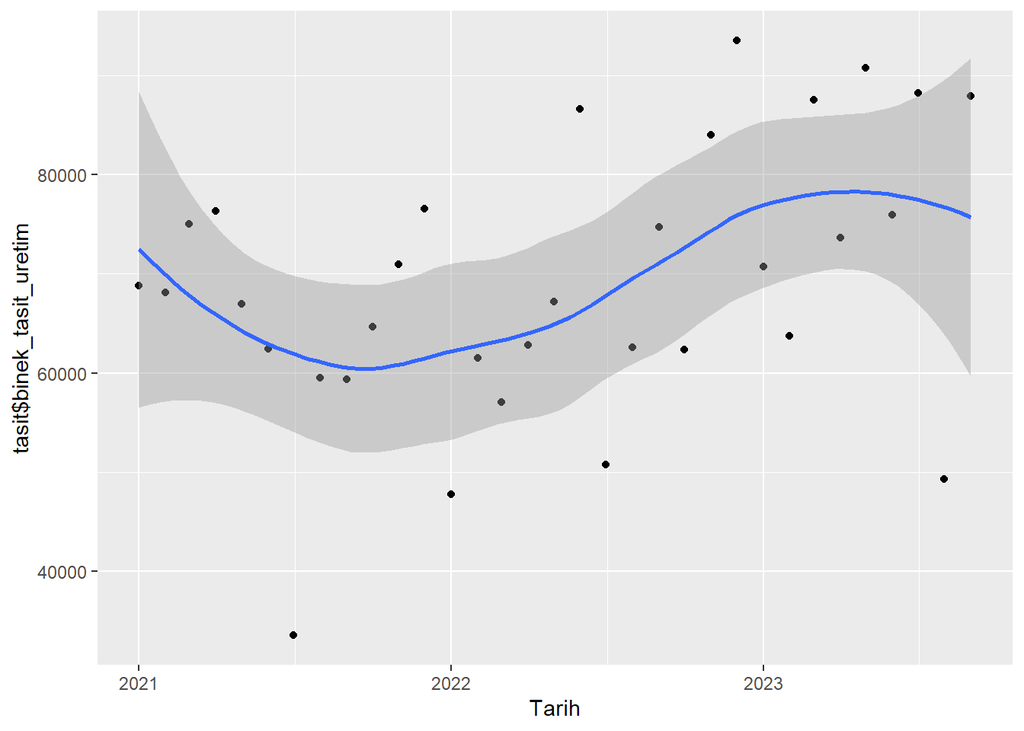

```r
ggplot(tasit ,aes(x=Tarih,y=tasit$binek_tasit_uretim)) + geom_point()+geom_smooth(method='loess')
```

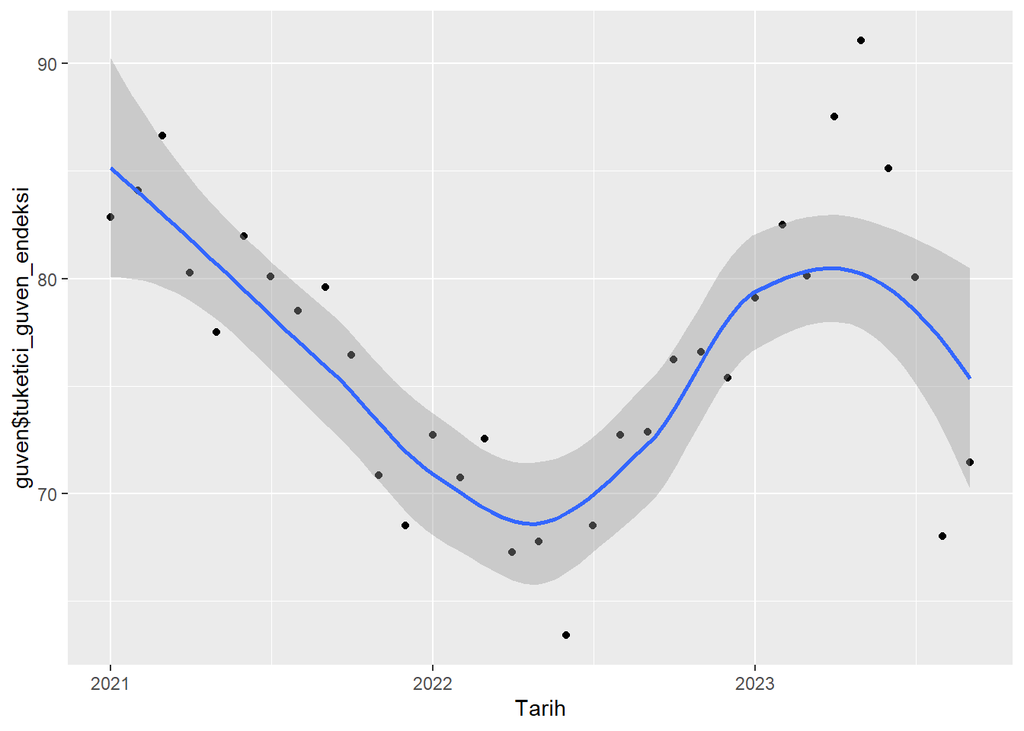

```r
ggplot(guven ,aes(x=Tarih,y=guven$tuketici_guven_endeksi)) + geom_point()+geom_smooth(method='loess')
```

No linear trend appears. There may be a polynomial trend.

## Implementation of dummy variables for seasonality and trend

```r
konut <- as.data.table(konut)
konut[,trnd:=1:.N]
konut[,ay:=as.character(month(Tarih,label=T))]
head(konut)
```

```
##         Tarih Konut_kredi_faizleri Antalya_isparta_Konut_fiyat_endeksi
##        <Date>                <num>                               <num>
## 1: 2021-01-01               18.388                               190.9
## 2: 2021-02-01               17.985                               195.0
## 3: 2021-03-01               17.735                               199.0
## 4: 2021-04-01               18.134                               206.2
## 5: 2021-05-01               17.835                               216.3
## 6: 2021-06-01               17.900                               222.4
##    Antalya_konut_satis  trnd     ay
##                  <num> <int> <char>
## 1:                3010     1    Oca
## 2:                3702     2    Şub
## 3:                5268     3    Mar
## 4:                4429     4    Nis
## 5:                2264     5    May
## 6:                5773     6    Haz
```

```r
tasit <- as.data.table(tasit)
tasit[,trnd:=1:.N]
tasit[,ay:=as.character(month(Tarih,label=T))]
head(tasit)
```

```
##         Tarih kapasite_kullanim ab_fiyat_endeksi binek_tasit_ihracat
##        <Date>             <num>            <num>               <num>
## 1: 2021-01-01              75.6         113.0832           110.32151
## 2: 2021-02-01              75.5         113.3194           115.18405
## 3: 2021-03-01              75.6         114.3823           134.34682
## 4: 2021-04-01              76.2         115.0373           116.79690
## 5: 2021-05-01              75.2         115.3380            92.06025
## 6: 2021-06-01              76.3         115.6386            84.00333
##    binek_tasit_uretim  trnd     ay
##                 <num> <int> <char>
## 1:              68777     1    Oca
## 2:              68105     2    Şub
## 3:              74995     3    Mar
## 4:              76334     4    Nis
## 5:              66976     5    May
## 6:              62441     6    Haz
```

```r
guven <- as.data.table(guven)
guven[,trnd:=1:.N]
guven[,ay:=as.character(month(Tarih,label=T))]
head(guven)
```

```
##         Tarih USD_Banka_Karti_ve_Kredi_Karti_Harcama_tutari issizlik_oranlar
##        <Date>                                         <num>            <num>
## 1: 2021-01-01                                      15546455             13.4
## 2: 2021-02-01                                      13992938             14.1
## 3: 2021-03-01                                      13981868             13.1
## 4: 2021-04-01                                      16022046             12.9
## 5: 2021-05-01                                      11931825             12.4
## 6: 2021-06-01                                      14922946             10.4
##    tuketici_guven_endeksi  trnd     ay
##                     <num> <int> <char>
## 1:               82.86952     1    Oca
## 2:               84.10742     2    Şub
## 3:               86.62952     3    Mar
## 4:               80.25357     4    Nis
## 5:               77.52774     5    May
## 6:               81.97084     6    Haz
```

## Seasonal trends

We examined the trends in each season (monthly).

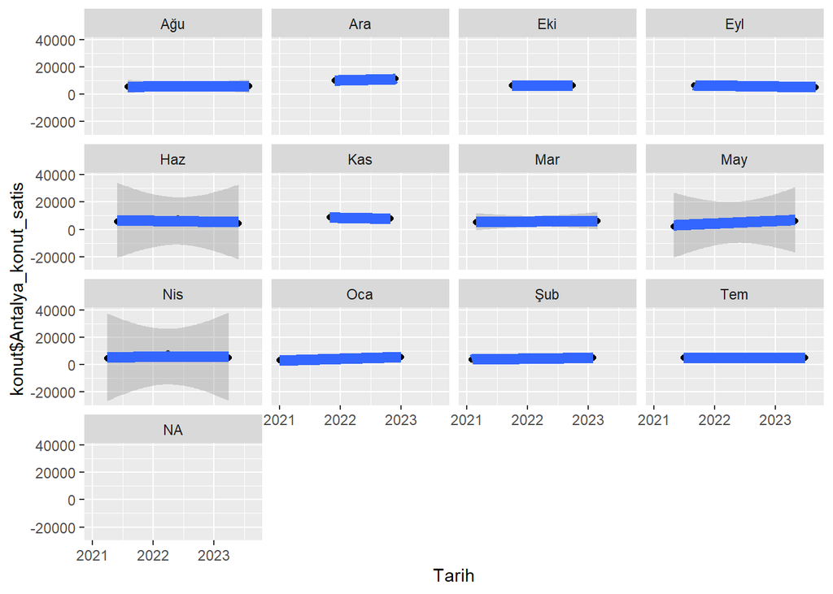

```r
ggplot(konut,aes(x=Tarih,y=konut$Antalya_konut_satis)) +
        geom_point() + geom_smooth(method=lm,linewidth=3) + facet_wrap(~ay)
```

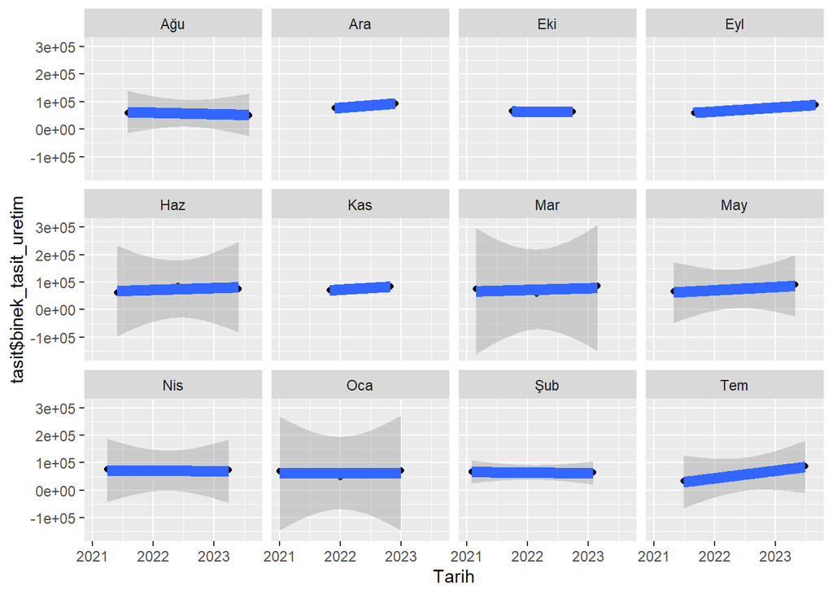

```r
ggplot(tasit,aes(x=Tarih,y=tasit$binek_tasit_uretim)) +
        geom_point() + geom_smooth(method=lm,linewidth=3) + facet_wrap(~ay)
```

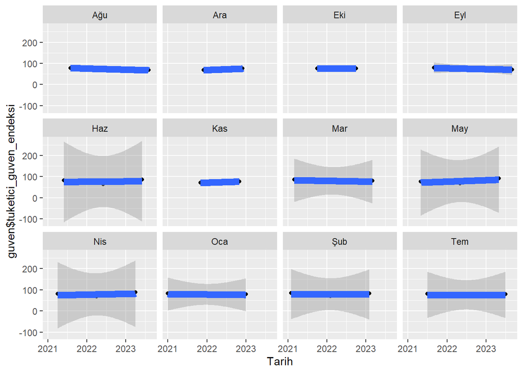

```r
ggplot(guven,aes(x=Tarih,y=guven$tuketici_guven_endeksi)) +
        geom_point() + geom_smooth(method=lm,linewidth=3) + facet_wrap(~ay)
```

As can be seen, the monthly impact is very low. This makes sense because we only have a few data for each month.

## Forecast models:

For Antlalya housing sales, housing loan interest and housing price index were in correlation. Therefore, I installed 2 different models. In one, I used both data, and in the other, I used only the house price index.

```r
lm_base=lm(konut$Antalya_konut_satis~trnd+ay+konut$Konut_kredi_faizleri+konut$Antalya_isparta_Konut_fiyat_endeksi,konut)
summary(lm_base)
```

```
##
## Call:
## lm(formula = konut$Antalya_konut_satis ~ trnd + ay + konut$Konut_kredi_faizleri +
##     konut$Antalya_isparta_Konut_fiyat_endeksi, data = konut)
##
## Residuals:
##     Min      1Q  Median      3Q     Max
## -2063.9  -459.5    75.3   477.7  1472.3
##
## Coefficients:
##                                            Estimate Std. Error t value Pr(>|t|)
## (Intercept)                                4320.269   1502.135   2.876 0.010051
## trnd                                        309.407    101.422   3.051 0.006882
## ayAra                                      4297.840    996.275   4.314 0.000418
## ayEki                                       162.093    987.250   0.164 0.871414
## ayEyl                                         9.298    870.538   0.011 0.991595
## ayHaz                                       427.419    905.423   0.472 0.642553
## ayKas                                      1977.099    992.872   1.991 0.061847
## ayMar                                       397.178    924.303   0.430 0.672510
## ayMay                                      -586.797    918.220  -0.639 0.530833
## ayNis                                       186.804    912.022   0.205 0.840008
## ayOca                                     -1167.321    891.410  -1.310 0.206827
## ayŞub                                     -1013.226    901.462  -1.124 0.275788
## ayTem                                      -839.784    863.812  -0.972 0.343843
## konut$Konut_kredi_faizleri                   19.627     65.163   0.301 0.766710
## konut$Antalya_isparta_Konut_fiyat_endeksi    -6.023      2.330  -2.585 0.018670
##
## (Intercept)                               *
## trnd                                      **
## ayAra                                     ***
## ayEki
## ayEyl
## ayHaz
## ayKas                                     .
## ayMar
## ayMay
## ayNis
## ayOca
## ayŞub
## ayTem
## konut$Konut_kredi_faizleri
## konut$Antalya_isparta_Konut_fiyat_endeksi *
## ---
## Signif. codes:  0 '***' 0.001 '**' 0.01 '*' 0.05 '.' 0.1 ' ' 1
##
## Residual standard error: 1054 on 18 degrees of freedom
##   (13 observations deleted due to missingness)
## Multiple R-squared:  0.8186, Adjusted R-squared:  0.6775
## F-statistic: 5.803 on 14 and 18 DF,  p-value: 0.0003672
```

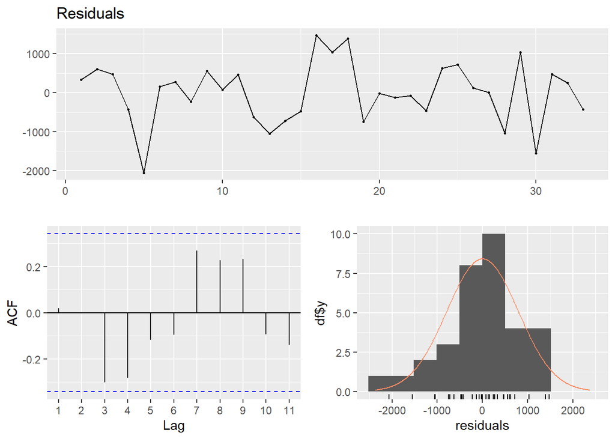

```
##
##  Ljung-Box test
##
## data:  Residuals
## Q* = 10.803, df = 7, p-value = 0.1475
##
## Model df: 0.   Total lags used: 7
```

```r
checkresiduals(lm_base$residuals)
```

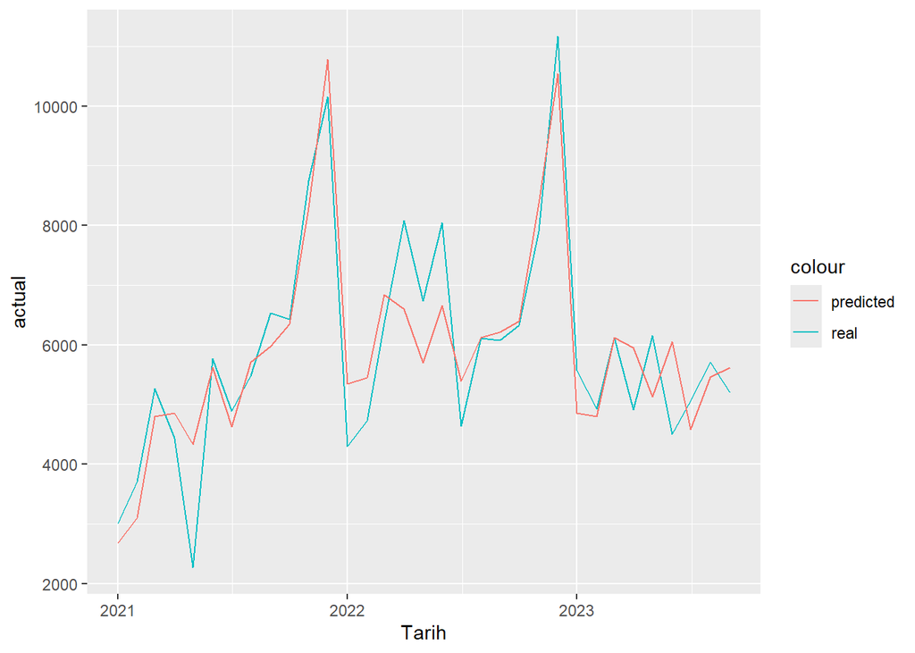

```r
tmp=copy(konut)
tmp[,actual:=Antalya_konut_satis]
tmp[,predicted_trend:=predict(lm_base,tmp)]
tmp[,residual_trend:=actual-predicted_trend]
#head(tmp)
ggplot(tmp ,aes(x=Tarih)) +
        geom_line(aes(y=actual,color='real')) +
        geom_line(aes(y=predicted_trend,color='predicted'))
```

```r
lm_base=lm(konut$Antalya_konut_satis~trnd+ay+konut$Antalya_isparta_Konut_fiyat_endeksi,konut)
summary(lm_base)
```

```
##
## Call:
## lm(formula = konut$Antalya_konut_satis ~ trnd + ay + konut$Antalya_isparta_Konut_fiyat_endeksi,
##     data = konut)
##
## Residuals:
##      Min       1Q   Median       3Q      Max
## -2032.78  -410.36    90.92   501.66  1529.33
##
## Coefficients:
##                                            Estimate Std. Error t value Pr(>|t|)
## (Intercept)                                4713.552    724.681   6.504 3.13e-06
## trnd                                        294.416     86.231   3.414 0.002909
## ayAra                                      4260.445    964.566   4.417 0.000296
## ayEki                                       137.680    960.085   0.143 0.887481
## ayEyl                                        47.803    840.244   0.057 0.955226
## ayHaz                                       343.486    840.610   0.409 0.687391
## ayKas                                      1953.940    965.913   2.023 0.057386
## ayMar                                       299.944    845.120   0.355 0.726564
## ayMay                                      -681.581    841.720  -0.810 0.428110
## ayNis                                        99.042    843.294   0.117 0.907739
## ayOca                                     -1223.484    850.577  -1.438 0.166585
## ayŞub                                     -1085.672    847.739  -1.281 0.215723
## ayTem                                      -862.175    839.762  -1.027 0.317461
## konut$Antalya_isparta_Konut_fiyat_endeksi    -5.581      1.768  -3.157 0.005190
##
## (Intercept)                               ***
## trnd                                      **
## ayAra                                     ***
## ayEki
## ayEyl
## ayHaz
## ayKas                                     .
## ayMar
## ayMay
## ayNis
## ayOca
## ayŞub
## ayTem
## konut$Antalya_isparta_Konut_fiyat_endeksi **
## ---
## Signif. codes:  0 '***' 0.001 '**' 0.01 '*' 0.05 '.' 0.1 ' ' 1
##
## Residual standard error: 1028 on 19 degrees of freedom
##   (13 observations deleted due to missingness)
## Multiple R-squared:  0.8177, Adjusted R-squared:  0.693
## F-statistic: 6.556 on 13 and 19 DF,  p-value: 0.0001418
```

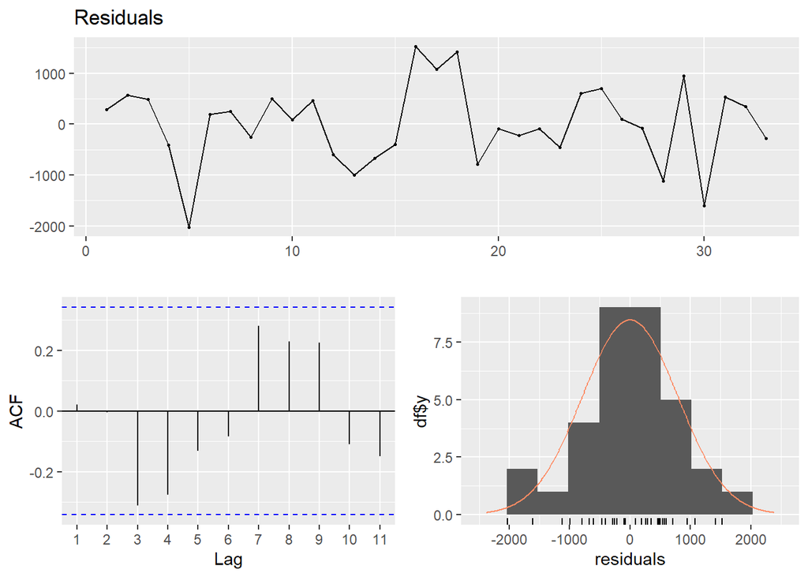

```
##
##  Ljung-Box test
##
## data:  Residuals
## Q* = 11.274, df = 7, p-value = 0.1271
##
## Model df: 0.   Total lags used: 7
```

```r
checkresiduals(lm_base$residuals)
```

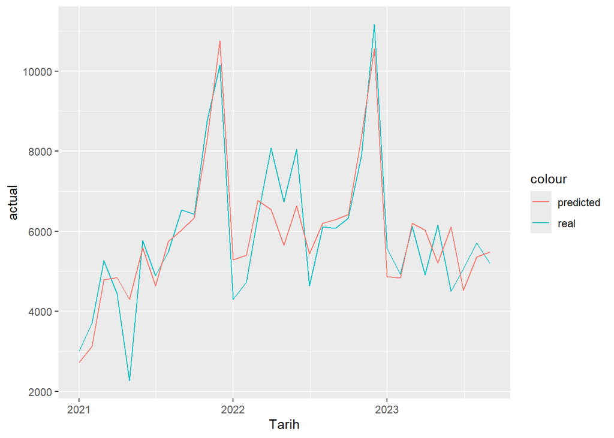

```r
tmp=copy(konut)
tmp[,actual:=Antalya_konut_satis]
tmp[,predicted_trend:=predict(lm_base,tmp)]
tmp[,residual_trend:=actual-predicted_trend]
#head(tmp)
ggplot(tmp ,aes(x=Tarih)) +
        geom_line(aes(y=actual,color='real')) +
        geom_line(aes(y=predicted_trend,color='predicted'))
```

The model in which we used only the house price index gave a slightly better r^2 value. The reason for this was to eliminate multicollinearity.

There is no seasonality and autocorrellation for residuals and they distribute like normal.

```r
lm_base=lm(tasit$binek_tasit_uretim~trnd+ay+tasit$kapasite_kullanim+tasit$ab_fiyat_endeksi+tasit$binek_tasit_ihracat,tasit)
summary(lm_base)
```

```
##
## Call:
## lm(formula = tasit$binek_tasit_uretim ~ trnd + ay + tasit$kapasite_kullanim +
##     tasit$ab_fiyat_endeksi + tasit$binek_tasit_ihracat, data = tasit)
##
## Residuals:
##    Min     1Q Median     3Q    Max
## -21044  -2548   -639   3532  18079
##
## Coefficients:
##                           Estimate Std. Error t value Pr(>|t|)
## (Intercept)               -26820.3   301196.9  -0.089   0.9301
## trnd                        -731.3     1346.6  -0.543   0.5941
## ayAra                      12676.8    12366.3   1.025   0.3197
## ayEki                        158.8    10626.8   0.015   0.9883
## ayEyl                      17421.2     8737.7   1.994   0.0625 .
## ayHaz                      13597.5     8983.8   1.514   0.1485
## ayKas                      14355.9    10146.8   1.415   0.1752
## ayMar                       7504.6     9406.3   0.798   0.4360
## ayMay                      15691.2     8775.1   1.788   0.0916 .
## ayNis                       9097.7     9193.2   0.990   0.3362
## ayOca                       5904.2     8638.3   0.683   0.5035
## ayŞub                       6183.9     8631.0   0.716   0.4834
## ayTem                       8375.6     8772.8   0.955   0.3531
## tasit$kapasite_kullanim    -1332.0     2233.2  -0.596   0.5587
## tasit$ab_fiyat_endeksi      1257.8     1824.1   0.690   0.4998
## tasit$binek_tasit_ihracat    411.1      158.4   2.595   0.0189 *
## ---
## Signif. codes:  0 '***' 0.001 '**' 0.01 '*' 0.05 '.' 0.1 ' ' 1
##
## Residual standard error: 10330 on 17 degrees of freedom
## Multiple R-squared:  0.6957, Adjusted R-squared:  0.4272
## F-statistic: 2.591 on 15 and 17 DF,  p-value: 0.03102
```

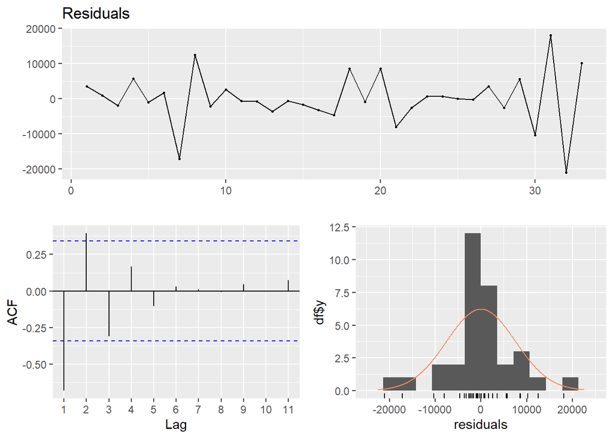

```
##
##  Ljung-Box test
##
## data:  Residuals
## Q* = 27.888, df = 7, p-value = 0.0002304
##
## Model df: 0.   Total lags used: 7
```

```r
checkresiduals(lm_base$residuals)
```

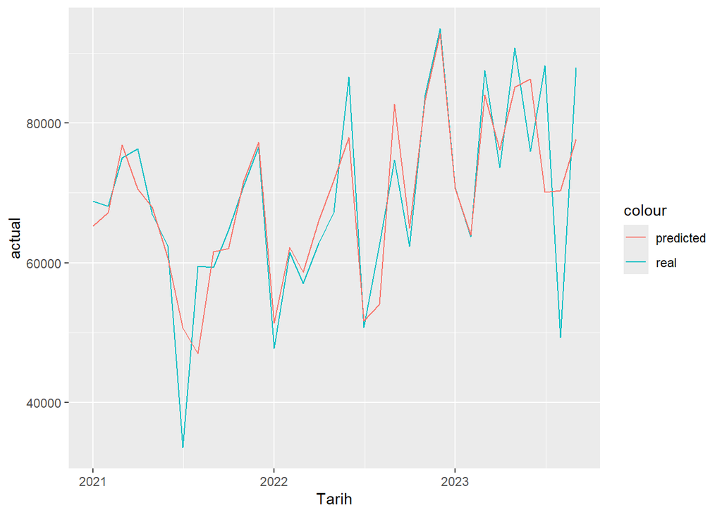

```r
tmp=copy(tasit)
tmp[,actual:=binek_tasit_uretim]
tmp[,predicted_trend:=predict(lm_base,tmp)]
tmp[,residual_trend:=actual-predicted_trend]
#head(tmp)
ggplot(tmp ,aes(x=Tarih)) +
        geom_line(aes(y=actual,color='real')) +
        geom_line(aes(y=predicted_trend,color='predicted'))
```

The performance of the model is not very good, and the lag1 value is quite high. We can try differencing to solve this problem.

```r
require(zoo)
lag1dif <- diff(zoo(tasit$binek_tasit_uretim),lag=1,differences = 1,na.pad = TRUE)
tasit$lag_dif <- lag1dif
tasit <- na.omit(tasit)
tasit$lag_dif <- as.numeric(tasit$lag_dif)
head(tasit)
```

```
##         Tarih kapasite_kullanim ab_fiyat_endeksi binek_tasit_ihracat
##        <Date>             <num>            <num>               <num>
## 1: 2021-02-01              75.5         113.3194           115.18405
## 2: 2021-03-01              75.6         114.3823           134.34682
## 3: 2021-04-01              76.2         115.0373           116.79690
## 4: 2021-05-01              75.2         115.3380            92.06025
## 5: 2021-06-01              76.3         115.6386            84.00333
## 6: 2021-07-01              76.4         115.5312            74.69555
##    binek_tasit_uretim  trnd     ay lag_dif
##                 <num> <int> <char>   <num>
## 1:              68105     2    Şub    -672
## 2:              74995     3    Mar    6890
## 3:              76334     4    Nis    1339
## 4:              66976     5    May   -9358
## 5:              62441     6    Haz   -4535
## 6:              33529     7    Tem  -28912
```

```r
lm_base=lm(tasit$lag_dif~trnd+ay+tasit$kapasite_kullanim+tasit$ab_fiyat_endeksi+tasit$binek_tasit_ihracat,tasit)
summary(lm_base)
```

```
##
## Call:
## lm(formula = tasit$lag_dif ~ trnd + ay + tasit$kapasite_kullanim +
##     tasit$ab_fiyat_endeksi + tasit$binek_tasit_ihracat, data = tasit)
##
## Residuals:
##    Min     1Q Median     3Q    Max
## -43675  -7658  -1672   8795  28650
##
## Coefficients:
##                            Estimate Std. Error t value Pr(>|t|)
## (Intercept)               -107310.3   582710.6  -0.184    0.856
## trnd                          333.2     2743.5   0.121    0.905
## ayAra                       -3802.0    23829.0  -0.160    0.875
## ayEki                       -7429.1    20532.0  -0.362    0.722
## ayEyl                       15313.4    16710.3   0.916    0.373
## ayHaz                       -2460.4    17268.8  -0.142    0.888
## ayKas                       10502.3    19540.1   0.537    0.598
## ayMar                        5905.7    18354.6   0.322    0.752
## ayMay                        3544.8    16877.5   0.210    0.836
## ayNis                       -4331.6    17782.0  -0.244    0.811
## ayOca                      -26400.7    18208.9  -1.450    0.166
## ayŞub                        1812.8    16597.2   0.109    0.914
## ayTem                      -14446.4    16814.6  -0.859    0.403
## tasit$kapasite_kullanim      1839.8     4288.4   0.429    0.674
## tasit$ab_fiyat_endeksi       -522.4     3642.4  -0.143    0.888
## tasit$binek_tasit_ihracat     241.9      310.7   0.779    0.448
##
## Residual standard error: 19760 on 16 degrees of freedom
## Multiple R-squared:  0.4051, Adjusted R-squared:  -0.1526
## F-statistic: 0.7264 on 15 and 16 DF,  p-value: 0.7294
```

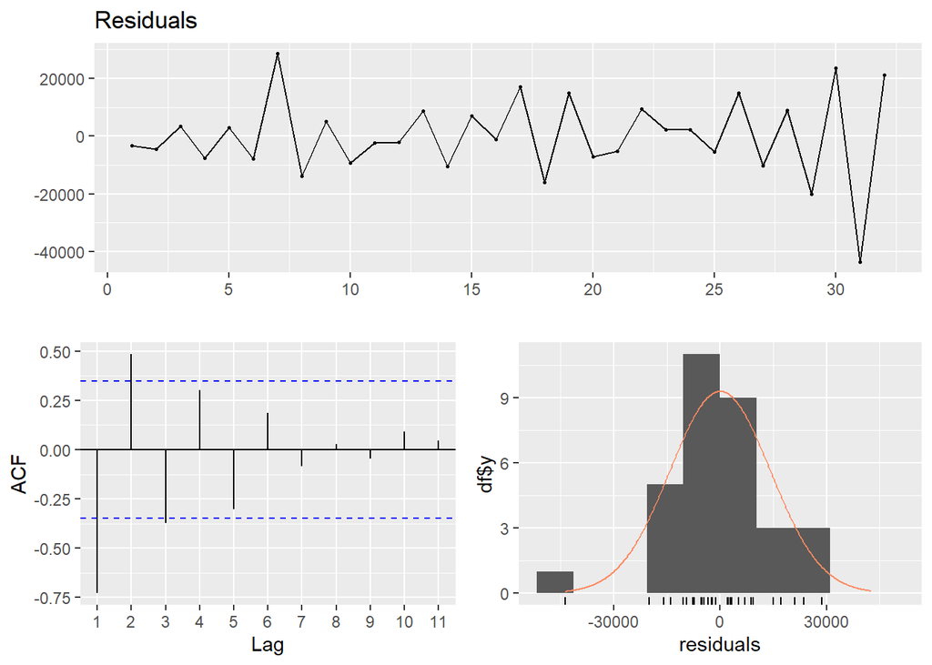

```
##
##  Ljung-Box test
##
## data:  Residuals
## Q* = 40.912, df = 6, p-value = 3.014e-07
##
## Model df: 0.   Total lags used: 6
```

```r
checkresiduals(lm_base$residuals)
```

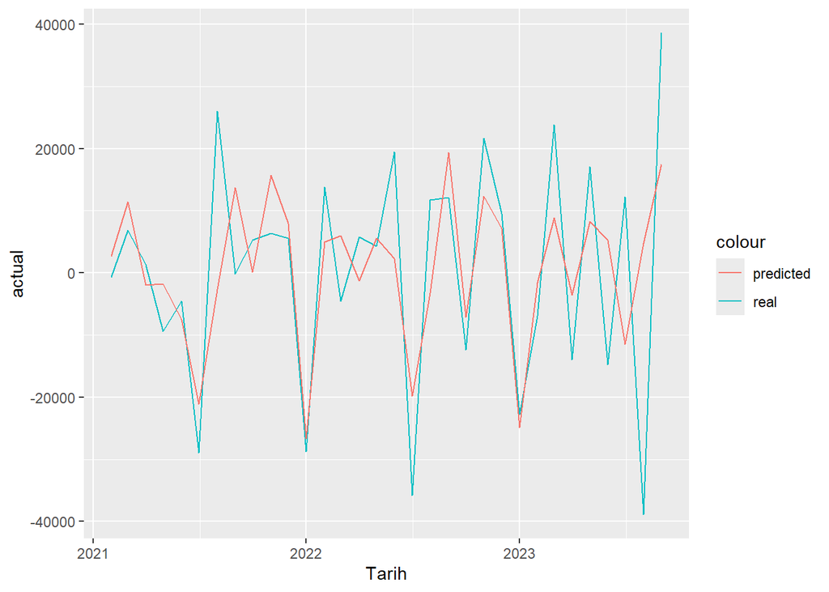

```r
tmp=copy(tasit)
tmp[,actual:=lag_dif]
tmp[,predicted_trend:=predict(lm_base,tmp)]
tmp[,residual_trend:=actual-predicted_trend]
#head(tmp)
ggplot(tmp ,aes(x=Tarih)) +
        geom_line(aes(y=actual,color='real')) +
        geom_line(aes(y=predicted_trend,color='predicted'))
```

Unfortunately, our solution method did not work. Lag1 remains high. And the r^2 value got worse. With this result, we can say that we do not have a good model.

```r
lm_base=lm(guven$tuketici_guven_endeksi~trnd+ay+USD_Banka_Karti_ve_Kredi_Karti_Harcama_tutari+guven$issizlik_oranlar,guven)
summary(lm_base)
```

```
##
## Call:
## lm(formula = guven$tuketici_guven_endeksi ~ trnd + ay + USD_Banka_Karti_ve_Kredi_Karti_Harcama_tutari +
##     guven$issizlik_oranlar, data = guven)
##
## Residuals:
##     Min      1Q  Median      3Q     Max
## -8.1401 -3.3483 -0.1351  3.3483  8.7050
##
## Coefficients:
##                                                 Estimate Std. Error t value
## (Intercept)                                    2.103e+01  4.178e+01   0.503
## trnd                                          -1.574e-01  4.816e-01  -0.327
## ayAra                                         -4.509e+00  5.996e+00  -0.752
## ayEki                                          3.558e+00  6.181e+00   0.576
## ayEyl                                         -3.799e+00  5.866e+00  -0.648
## ayHaz                                          4.144e+00  6.199e+00   0.668
## ayKas                                          2.683e+00  5.966e+00   0.450
## ayMar                                          2.328e+00  5.737e+00   0.406
## ayMay                                          6.434e+00  5.341e+00   1.205
## ayNis                                          1.285e+00  5.466e+00   0.235
## ayOca                                          3.482e+00  6.078e+00   0.573
## ayŞub                                          3.819e+00  6.518e+00   0.586
## ayTem                                         -9.102e-01  5.433e+00  -0.168
## USD_Banka_Karti_ve_Kredi_Karti_Harcama_tutari  1.125e-06  3.953e-07   2.847
## guven$issizlik_oranlar                         3.184e+00  3.397e+00   0.937
##                                               Pr(>|t|)
## (Intercept)                                     0.6208
## trnd                                            0.7476
## ayAra                                           0.4618
## ayEki                                           0.5720
## ayEyl                                           0.5254
## ayHaz                                           0.5123
## ayKas                                           0.6583
## ayMar                                           0.6897
## ayMay                                           0.2440
## ayNis                                           0.8168
## ayOca                                           0.5738
## ayŞub                                           0.5652
## ayTem                                           0.8688
## USD_Banka_Karti_ve_Kredi_Karti_Harcama_tutari   0.0107 *
## guven$issizlik_oranlar                          0.3610
## ---
## Signif. codes:  0 '***' 0.001 '**' 0.01 '*' 0.05 '.' 0.1 ' ' 1
##
## Residual standard error: 6.453 on 18 degrees of freedom
## Multiple R-squared:  0.4757, Adjusted R-squared:  0.06794
## F-statistic: 1.167 on 14 and 18 DF,  p-value: 0.3733
```

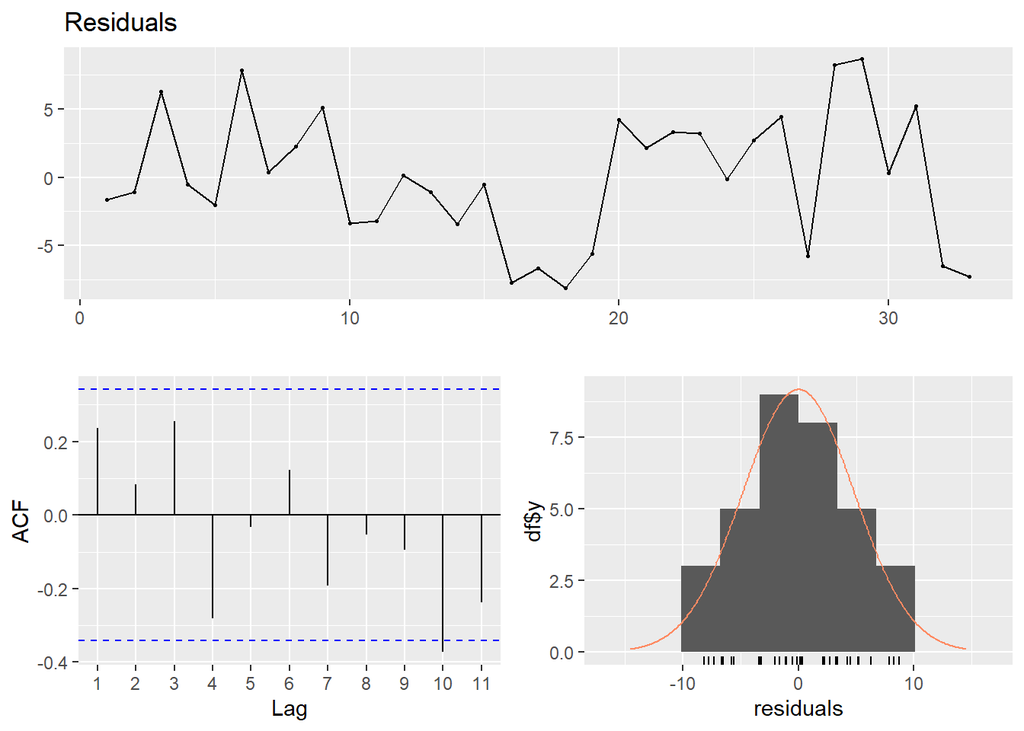

```
##
##  Ljung-Box test
##
## data:  Residuals
## Q* = 10.268, df = 7, p-value = 0.1739
##
## Model df: 0.   Total lags used: 7
```

```r
checkresiduals(lm_base$residuals)
```

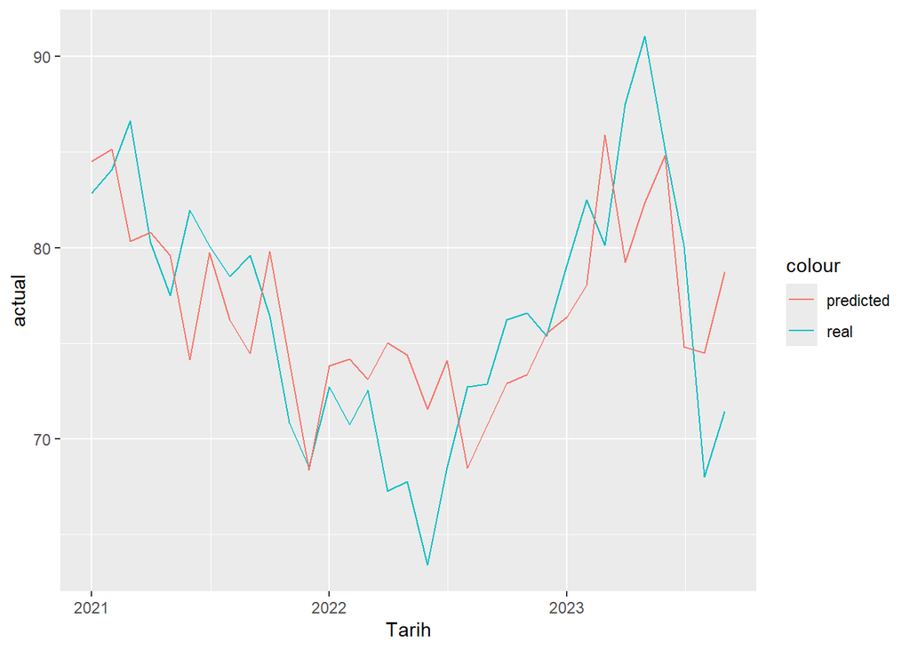

```r
tmp=copy(guven)
tmp[,actual:=tuketici_guven_endeksi]
tmp[,predicted_trend:=predict(lm_base,tmp)]
tmp[,residual_trend:=actual-predicted_trend]
#head(tmp)
ggplot(tmp ,aes(x=Tarih)) +
        geom_line(aes(y=actual,color='real')) +
        geom_line(aes(y=predicted_trend,color='predicted'))
```

The residues are distributed normally. There does not appear to be any autocorrelation. However, the r^2 value is quite bad. Adding a new variabla to the model may solve this problem.